# Neural_Network_Bank_Churn_Prediction

### **Building a model and looking/tuning the hyperparameter with GridSearch CV**

```python
backend.clear_session()
np.random.seed(42)
import random
random.seed(42)
tf.random.set_seed(42)
```

```python
def create_model_v5(lr,batch_size,):
    np.random.seed(1337)
    model = Sequential()
    model.add(Dense(64,activation='relu',input_dim = X_train.shape[1]))
    model.add(Dropout(0.3))
    model.add(Dense(32,activation='relu'))
    model.add(Dropout(0.3))
    model.add(Dense(1, activation='sigmoid'))

    #compile model
    optimizer = tf.keras.optimizers.Adam(learning_rate=lr)
    model.compile(optimizer = optimizer,loss = 'binary_crossentropy', metrics = ['accuracy'])
    return model
```

```python
keras_estimator = KerasClassifier(build_fn=create_model_v5, verbose=1)
# define the grid search parameters
param_grid = {
    'batch_size':[64,40, 128],
    "lr":[0.01,0.1,0.001],}

kfold_splits = 3
grid = GridSearchCV(estimator=keras_estimator,
                    verbose=1,
                    cv=kfold_splits,
                    param_grid=param_grid,n_jobs=-1)
```

```python
import time

# store starting time
begin = time.time()


grid_result = grid.fit(X_train, y_train,validation_split=0.2,verbose=1)

# Summarize results
print("Best: %f using %s" % (grid_result.best_score_, grid_result.best_params_))
means = grid_result.cv_results_['mean_test_score']
stds = grid_result.cv_results_['std_test_score']
params = grid_result.cv_results_['params']

time.sleep(1)
# store end time
end = time.time()

# total time taken
print(f"Total runtime of the program is {end - begin}")
```

```
Fitting 3 folds for each of 9 candidates, totalling 27 fits
Best: 0.817125 using {'batch_size': 40, 'lr': 0.01}
Total runtime of the program is 32.364609241485596
```

### **Creating the final model with the obtained configuration after hyperparameter tuning**

The runnning the model with the following configuration:

**Result of Grid Search**

{'batch_size': 40, 'learning_rate": 0.01}

Let's create the final model with the above mentioned configuration

```python
estimator_v5=create_model_v5(batch_size=grid_result.best_params_['batch_size'],lr=grid_result.best_params_['lr'])

estimator_v5.summary()
```

```
Model: "sequential_1"
_________________________________________________________________
 Layer (type)                Output Shape              Param #
=================================================================
 dense_3 (Dense)             (None, 64)                704

 dropout_2 (Dropout)         (None, 64)                0

 dense_4 (Dense)             (None, 32)                2080

 dropout_3 (Dropout)         (None, 32)                0

 dense_5 (Dense)             (None, 1)                 33

=================================================================
Total params: 2,817
Trainable params: 2,817
Non-trainable params: 0
_________________________________________________________________
```

```python
# Using Adam optimizer with the best learning rate
optimizer = tf.keras.optimizers.Adam(grid_result.best_params_['lr'])
estimator_v5.compile(loss='binary_crossentropy',optimizer=optimizer,metrics=['accuracy'])
history_5=estimator_v5.fit(X_train, y_train, epochs=100, batch_size = 40, verbose=1,validation_split=0.2)
```

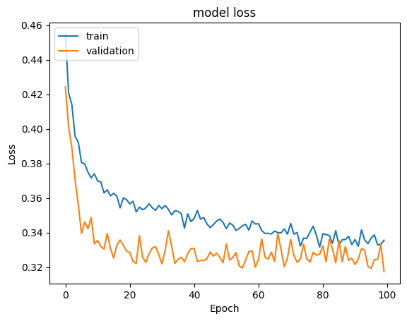

```python
#Plotting Train Loss vs Validation Loss
plt.plot(history_5.history['loss'])
plt.plot(history_5.history['val_loss'])
plt.title('model loss')
plt.ylabel('Loss')
plt.xlabel('Epoch')
plt.legend(['train', 'validation'], loc='upper left')
plt.show()
```

- There is noise in the loss behavior here. Due to the fluctuation of the loss function during training, this makes the convergence slow.
- We will search for an optimal threshold see if we can improve the metrics

```
Best Threshold=0.272641, G-Mean=0.792
```

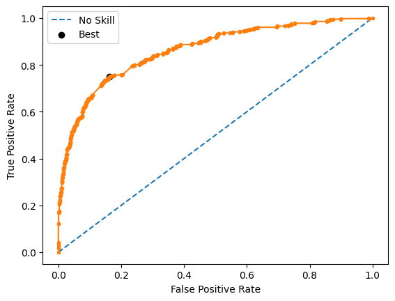

```python
from sklearn.metrics import roc_curve

from matplotlib import pyplot


# predict probabilities
yhat5 = estimator_v5.predict(X_test)
# keep probabilities for the positive outcome only
yhat5 = yhat5[:, 0]
# calculate roc curves
fpr, tpr, thresholds5 = roc_curve(y_test, yhat5)
# calculate the g-mean for each threshold
gmeans5 = np.sqrt(tpr * (1-fpr))
# locate the index of the largest g-mean
ix = np.argmax(gmeans5)
print('Best Threshold=%f, G-Mean=%.3f' % (thresholds5[ix], gmeans5[ix]))
# plot the roc curve for the model
pyplot.plot([0,1], [0,1], linestyle='--', label='No Skill')
pyplot.plot(fpr, tpr, marker='.')
pyplot.scatter(fpr[ix], tpr[ix], marker='o', color='black', label='Best')
# axis labels
pyplot.xlabel('False Positive Rate')
pyplot.ylabel('True Positive Rate')
pyplot.legend()
# show the plot
pyplot.show()
```

- Using a threshold of 0.27 to get better metrics of the model.

```python
y_pred_5=estimator_v5.predict(X_test)
y_pred_5 = (y_pred_5 > thresholds5[ix])
y_pred_5
```

```
array([[False],
       [False],
       [False],
       ...,
       [ True],
       [False],
       [False]])
```

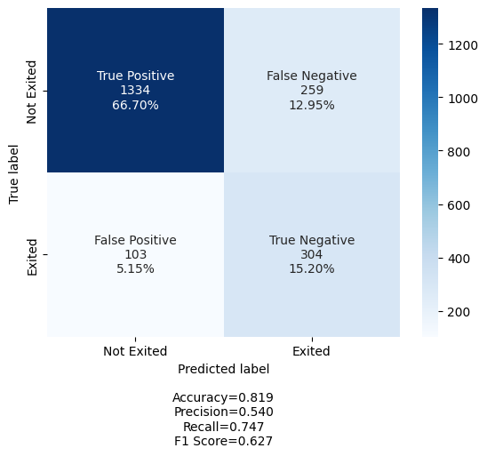

```python
#Calculating the confusion matrix
from sklearn.metrics import confusion_matrix
cm5=confusion_matrix(y_test, y_pred_5)
labels = ['True Positive','False Negative','False Positive','True Negative']
categories = [ 'Not Exited','Exited']
make_confusion_matrix(cm5,
                      group_names=labels,
                      categories=categories,
                      cmap='Blues')
```

- With an optimal threshold we can see we have a better Recall score and good accuracy score. However our False negative increased, we except to have a minimized false negtive in other to have better true postives.

#### **Our model can be baised due to class imbalance. Therefore applying SMOTE to the dataset to help in mitigating issue associated with class imbalance, such as biased classification due to majority class. In this dataset Our minority class here is class (1) Exited**

```python
## Applying SMOTE on train data
from imblearn.over_sampling import SMOTE
smote=SMOTE(sampling_strategy='not majority')
X_sm , y_sm = smote.fit_resample(X_train,y_train)
print('After UpSampling, the shape of train_X: {}'.format(X_sm.shape))
print('After UpSampling, the shape of train_y: {} \n'.format(y_sm.shape))
```

```
After UpSampling, the shape of train_X: (12740, 10)
After UpSampling, the shape of train_y: (12740, 1)
```

```python
# Display shape of the independent data after oversampling
X_sm.shape
```

```
(12740, 10)
```

```python
y_sm["Exited"].value_counts(1)
```

```
1    0.5
0    0.5
Name: Exited, dtype: float64
```

#### **Build model 6 after applying oversampling to the minority class, using a balanced Dataset**

```python
backend.clear_session()
np.random.seed(42)
import random
random.seed(42)
tf.random.set_seed(42)
```

```python
model6 = Sequential()
# Add input layer and first hidden layer of 32 neurons with relu as activation function
model6.add(Dense(64,activation='relu',input_dim = X_train.shape[1]))
# Add dropout rate of 0.2 to first hidden layer
#model6.add(Dropout(0.2))
# Add second hidden layer of 16 neurons with relu as activation function
model6.add(Dense(32,activation='relu'))
#model6.add(Dropout(0.1))
# Add third hidden layer of 8 neurons with relu as activation function
model6.add(Dense(16,activation='relu'))
# Add output layer of 1 neuron with sigmoid as activation function
model6.add(Dense(1, activation = 'sigmoid'))
```

```python
#Compiling the ANN with Adam optimizer and binary cross entropy loss function
optimizer = tf.keras.optimizers.Adam(0.001)
model6.compile(loss='binary_crossentropy',optimizer=optimizer,metrics=['accuracy'])
```

```python
model6.summary()
```

[output not shown]

```python
# Defining Early stopping
from keras import callbacks
es_cb = callbacks.EarlyStopping(monitor='val_loss', min_delta=0.001, patience=5)

# Initializing Adam optimizer
optimizer = tf.keras.optimizers.Adam(0.001)

# Compile the model with binary cross entropy as loss and accuracy as metrics
model6.compile(optimizer = optimizer,loss = 'binary_crossentropy', metrics = ['accuracy'])
```

```python
# fit the model on train with batch_size of 64, epochs of 100 and callbacks as earlystopping
history6 = model6.fit(X_sm,y_sm,batch_size=64,epochs=100,verbose=1,validation_split = 0.2,callbacks=[es_cb])
```

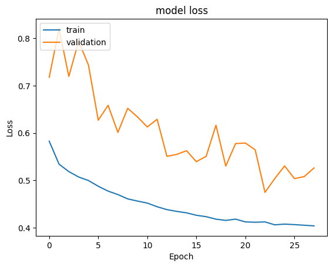

```python
#Plotting Train Loss vs Validation Loss
plt.plot(history6.history['loss'])
plt.plot(history6.history['val_loss'])
plt.title('model loss')
plt.ylabel('Loss')
plt.xlabel('Epoch')
plt.legend(['train', 'validation'], loc='upper left')
plt.show()
```

- There is obviosly overfitting with the model and the loss function is very poor here as well as the accuracy. Hence even with a balanced dataset we are not able to get a model that generalizes between the train and validation set
- We will attempt to improve the model's prediction metrics by searching for optimal threshold.

```
Best Threshold=0.398882, G-Mean=0.775
```

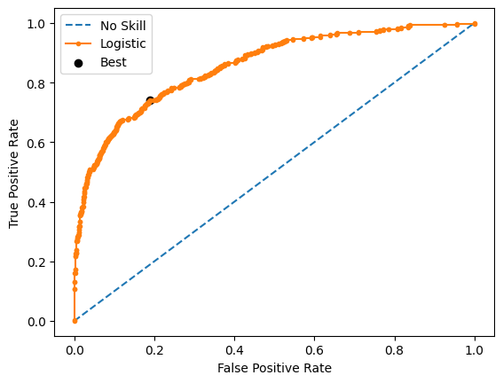

```python
from sklearn.metrics import roc_curve

from matplotlib import pyplot


yhat6 = model6.predict(X_test)

# keep probabilities for the positive outcome only
yhat6 = yhat6[:, 0]
# calculate roc curves
fpr, tpr, thresholds6 = roc_curve(y_test, yhat6)
# calculate the g-mean for each threshold
gmeans = np.sqrt(tpr * (1-fpr))
# locate the index of the largest g-mean
ix = np.argmax(gmeans)
print('Best Threshold=%f, G-Mean=%.3f' % (thresholds6[ix], gmeans[ix]))
# plot the roc curve for the model
pyplot.plot([0,1], [0,1], linestyle='--', label='No Skill')
pyplot.plot(fpr, tpr, marker='.', label='Logistic')
pyplot.scatter(fpr[ix], tpr[ix], marker='o', color='black', label='Best')
# axis labels
pyplot.xlabel('False Positive Rate')
pyplot.ylabel('True Positive Rate')
pyplot.legend()
# show the plot
pyplot.show()
```

```python
y_pred6=model6.predict(X_test)
y_pred6 = (y_pred6 > thresholds6[ix])
y_pred6
```

```
array([[False],
       [False],
       [False],
       ...,
       [ True],
       [False],
       [False]])
```

```python
from sklearn import metrics
cr=metrics.classification_report(y_test,y_pred6)
print(cr)
```

```
              precision    recall  f1-score   support

           0       0.92      0.81      0.86      1593
           1       0.50      0.74      0.60       407

    accuracy                           0.80      2000
   macro avg       0.71      0.77      0.73      2000
weighted avg       0.84      0.80      0.81      2000
```

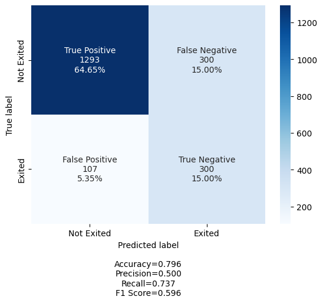

```python
#Calculating the confusion matrix
from sklearn.metrics import confusion_matrix
cm6=confusion_matrix(y_test, y_pred6)
labels = ['True Positive','False Negative','False Positive','True Negative']
categories = [ 'Not Exited','Exited']
make_confusion_matrix(cm6,
                      group_names=labels,
                      categories=categories,
                      cmap='Blues')
```

- Even though the recall and accuracy is okay the false negative is higher than expected and will fail to accurately predict the true positives.
- Oversampling using SMOTE did not help improve the models recall score.

### Actionable Insights and Recommendations

- Our best model is **model 4** using dropout regularization with imbalanced dataset.
- Using model architecture of first 32, 16 and 8 in the three hiddden layers we achieved a much more generalized model with the training and validation set, with high recall score of 74% metrics on the test dataset as well as high accuracy.
- The older customers are churning at more than the younger ones alluding to a difference in service preference in the age categories. The bank may need to review its target market or review the strategy for retention between the different age groups.
- About the tenure, the clients on either end (spent little time with the bank or a lot of time with the bank) are more likely to churn compared to those that are of average tenure. Worryingly, the bank is losing customers with significant bank balances which are likely to hit their available capital for lending.
- The proportion of female customers churning is also greater than that of male customers. Interestingly, the majority of the customers that churned are those with credit cards. Given that majority of the customers have credit cards could prove this to be just a coincidence.
- Unsurprisingly the inactive members have a greater churn. Worryingly is that the overall proportion of inactive members is quite high suggesting that the bank may need a program implemented to turn this group into active customers as this will have a positive impact on the customer churn.
- The bank can deploy the final model (Model 4) from this analysis to identify with a reasonable degree of accuracy whether a customer is likely to exit the bank or not, and this process seems to be easier and more time-efficient than other methods.
- The optimised model gives better results as seen from the confusion matrix as well as an improved recall score.
- The model is able to predict high level true positives and very low false negatives hence recall/accuracy metrics is maximized.